# Estadística Aplicada 3 - Tarea 1

Autor/a

Marcelino

Fecha de publicación

16 de octubre de 2023

```r
#Cargamos paquetes
library(tidymodels)
library(discrim)
library(corrr)
library(paletteer)
library(MASS)
library(dslabs)
library(tidyr)

# Cargamos bases de datos
data2 <- iris
```

# 1.- Derive la probabilidad de mala clasificación para LDA

La probabilidad de mala clasificación binaria en LDA (guassiano) es

$$P(\Delta)=P(\mathbf{x}\in R_{2}|\mathbf{x}\in \Pi_{1})\pi_{1}+P(\mathbf{x}\in R_{1}|\mathbf{x}\in \Pi_{2})\pi_{2}$$

donde tenemos que

$$P(\mathbf{x}\in R_{2}|\mathbf{x}\in \Pi_{1})\pi_{1} = P(L(\mathbf{x})<0|\mathbf{x}\in\Pi_{1})$$

Donde aquí consideramos que $L(\mathbf{x})$ es la función discriminante de LDA, $R_{2}$ es la región de decisión para la clase 2, y $\pi_{1}$ ,$\pi_{2}$ son las probabilidades a priori de las clases 1 y 2 respectivamente:

$$L(\mathbf{x})=\ln\left(\frac{f_{1}(x)\pi_{1}}{f_{2}(x)\pi_{2}}\right)= \ln\left(\frac{f_{1}(x)}{f_{2}(x)}\right)+ \ln\left(\frac{\pi_{1}}{\pi_{2}}\right)$$

Con lo cual desarrollando (usando propiedades de logaritmo) obtenemos la siguiente expresión:

$$L(\mathbf{x})=\ln(f_{1}(x))-\ln(f_{2}(x))+ \ln\left(\frac{\pi_{1}}{\pi_{2}}\right)=$$

$$\ln(f_{1}(x))-\ln(f_{2}(x))+ \ln\left(\frac{\pi_{1}}{\pi_{2}}\right)=$$

$$\ln \left(\frac{1}{\sqrt{(2\pi)^{k} |\Sigma|}} \exp\left(-\frac{1}{2} (\mathbf{x} - \mu_{1})^T \Sigma^{-1} (\mathbf{x} - \mu_{1})\right)\right)$$

$$-\ln \left( \frac{1}{\sqrt{(2\pi)^k |\Sigma|}} \exp\left(-\frac{1}{2} (\mathbf{x} - \mu_{2})^T \Sigma^{-1} (\mathbf{x} - \mu_{2})\right)\right)+ \ln\left(\frac{\pi_{1}}{\pi_{2}}\right)=$$

$$\left(-\frac{1}{2} (\mathbf{x} - \mu_{1})^T \Sigma^{-1} (\mathbf{x} - \mu_{1})\right)-$$

$$\left(-\frac{1}{2} (\mathbf{x} - \mu_{2})^T \Sigma^{-1} (\mathbf{x} - \mu_{2})\right)+ \ln\left(\frac{\pi_{1}}{\pi_{2}}\right)=$$

A parti de aquí aplicamos las propiedades de simetría de $\Sigma$ y además con el desarrollo algebraico obtenemos:

$$L(\mathbf{x})=\left(-\frac{1}{2}\left(\mu_{1}^T \Sigma^{-1} \mu_{1}-\mu_{2}^T \Sigma^{-1} \mu_{2}\right)+ \ln\left(\frac{\pi_{1}}{\pi_{2}}\right)\right)+$$

$$\mu_{1}^T \Sigma^{-1}\mathbf{x}- \mu_{2}^T \Sigma^{-1}\mathbf{x}$$

Con lo cual podemos reescribir la expresión como:

$$L(\mathbf{x})= b_{0} + \mathbf{b}'\mathbf{x}$$

donde

$$b_{0}=-\frac{1}{2}\left(\mu_{1}^T \Sigma^{-1} \mu_{1}-\mu_{2}^T \Sigma^{-1} \mu_{2}\right)+ \ln\left(\frac{\pi_{1}}{\pi_{2}}\right)$$

$$\mathbf{b}=\Sigma^{-1}(\mu_{1}-\mu_{2})$$

Ahora volviendo a lo que nos concierne, considerando la probabilidad condicional, tendríamos la siguiente igualdad:

$$P(L(\mathbf{x})<0|\mathbf{x}\in\Pi_{1})=P_{\Pi_{1}}(b_{0} + \mathbf{b}'\mathbf{x}<0)=$$

Ahora estandarizamos la expresión:

$$P_{\Pi_{1}}\left(\frac{\mathbf{b}'\mathbf{x}-\mathbf{b}'\mu_{1}}{\sqrt{(b'\Sigma b)}}<-\frac{(b_{0}+ \mathbf{b}'\mu_{1})}{\sqrt{b'\Sigma b}}\right)=\Phi\left(-\frac{(b_{0}+ \mathbf{b}'\mu_{1})}{\sqrt{b'\Sigma b}}\right)$$

y análogamente para la otra probabilidad que tendríamos que calcular tendríamos:

$$P(\mathbf{x}\in R_{1}|\mathbf{x}\in \Pi_{2})=\Phi\left(\frac{(b_{0}+ \mathbf{b}'\mu_{2})}{\sqrt{b'\Sigma b}}\right)$$

Con lo cual la probabilidad de error de clasificación es el siguiente:

$$P(\Delta)=\Phi\left(-\frac{(b_{0}+ \mathbf{b}'\mu_{1})}{\sqrt{b'\Sigma b}}\right)\pi_{1}+\Phi\left(\frac{(b_{0}+ \mathbf{b}'\mu_{2})}{\sqrt{b'\Sigma b}}\right)\pi_{2}$$

2. **Implementar LDA sobre la base de datos `MNIST` y usar los dígitos 1 y 3**

La implementación en R fue usando la librería de `MASS` para el método de LDA, y la librería `dslabs` para acceder a los datos de MNIST

Se inicializan los datos de la siguiente forma:

```r
mnist_data <- read_mnist()
```

Los datos ya vienen divididos en variables `train` y `test`, las que a su vez contienen `images` y `labels`.

Ahora, los datos de imágenes 28x28 vienen en forma de vectores de 784 entradas, con valores del 0 al 255 representando la gamma del gris. Debido a su fuerte correlación entre pixeles adyacentes, es importante reducir la colinearidad al tomar en vez un estadístico de los pixeles que nos ayude todavía a diferenciarlos. Para esto, decidimos tomar el promedio de los renglones de la imagen para determinar cuánto está dibujado de negro cada fila en la imagen; un dato que debe ayudarnos en general a distinguir 1s de 3s.

```r
#Extraer el train y test
tri <- train_images <- mnist_data$train$images
train_labels<-mnist_data$train$labels
tei <- test_images <- mnist_data$test$images
test_labels <- mnist_data$test$labels

#Transformar el train al estadístico que deseamos de solo 1 y 3
tr_ind <- (train_labels == 1) | (train_labels==3)
train_labels <- train_labels[tr_ind]
tri <- tri[tr_ind,]
tri2 <- array(tri, dim=c(dim(tri)[1],28,28))
tri_promr <- rowMeans(tri2, dims = 2)

#Transformar el test al estadístico que deseamos de solo 1 y 3
te_ind <- (test_labels == 1) | (test_labels==3)
test_labels <- test_labels[te_ind]
tei <- tei[te_ind,]
tei2 <- array(tei, dim=c(dim(tei)[1],28,28))
tei_promr <- rowMeans(tei2, dims = 2)
```

Una vez hecho eso, ahora aplicamos el algoritmo de LDA para crear el predictor, construyendo la matriz (Y,X) para insertar al modelo.

```r
train <- data.frame(label = (train_labels == 1),tri_promr)

model <- lda(label~.,data=train)
```

Una vez entrenado, ahora lo ponemos a prueba con el set de `test`, y medimos la precisión.

```r
test <- data.frame(label = (test_labels == 1),tei_promr)


prob <- predict(model, test, method = "debiased") #, type = "response")
pred <- ifelse(prob$posterior[,2] > 0.5, 1, 3)

sum(pred == test_labels) / length(test_labels) #precisión de predictor
```

```
[1] 0.8899767
```

Con ello, obtenemos al final los resultados del experimento, lo cual nos da:

```r
prob <- predict(model, test, method = "debiased") #, type = "response")
pred <- ifelse(prob$posterior[,2] > 0.5, 1, 3)
sum(pred == test_labels) / length(test_labels) #precisión de predictor
```

```
[1] 0.8899767
```

Eso nos da una precisión del 88.99%, bastante alto para un predictor lineal de clases entre 1 y 3. Con ello, se conluye el problema.

# 3.- Implementar QDA sobre los datos de `iris` (raw data)

Vamos a implementar QDA en los datos de `iris` utilizando datos de entrenamiento y testeo dado que no queremos causar un sobreajuste en los datos.

Utilizaremos el 75% de los datos para entranamiento y la semilla 1087.

```r
set.seed(1087)
data_split <- rsample::initial_split(data2, prop = .75)
data_train <- training(data_split)
data_test <- testing(data_split)

qda_spec <- discrim_quad() |>
  set_mode("classification") |>
  set_engine("MASS")

qda_fit <- qda_spec |>
  fit(Species ~ ., data = data_train)
```

Ahora calcularemos métricas para saber qué tan bien estuvo nuestro ajuste.

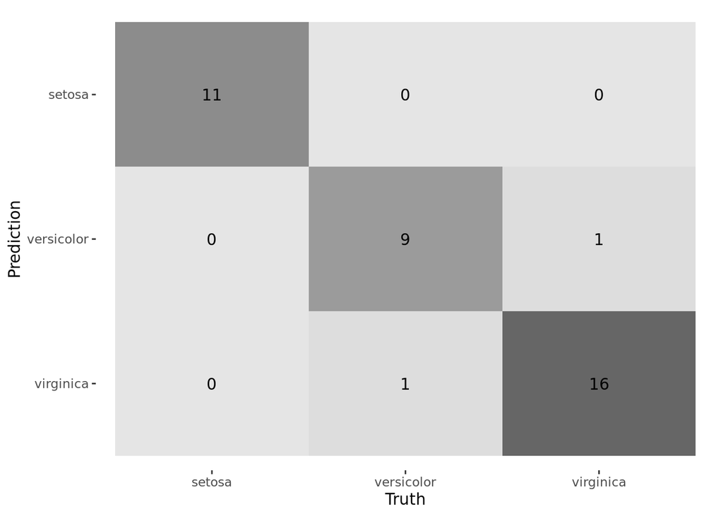

```r
augment(qda_fit, new_data = data_test) |>
  conf_mat(truth = Species, estimate = .pred_class) |>
  autoplot(type = "heatmap")
```

```r
augment(qda_fit, new_data = data_test) |>
  accuracy(truth = Species, estimate = .pred_class)
```

```
# A tibble: 1 × 3
  .metric  .estimator .estimate
  <chr>    <chr>          <dbl>
1 accuracy multiclass     0.947
```

```r
augment(qda_fit, new_data = data_test) |>
  recall(truth = Species, estimate = .pred_class)
```

```
# A tibble: 1 × 3
  .metric .estimator .estimate
  <chr>   <chr>          <dbl>
1 recall  macro          0.947
```

```r
augment(qda_fit, new_data = data_test) |>
  precision(truth = Species, estimate = .pred_class)
```

```
# A tibble: 1 × 3
  .metric   .estimator .estimate
  <chr>     <chr>          <dbl>
1 precision macro          0.947
```

Con lo cual notamos que tuvimos un muy buen ajuste, dado que entre más cercano a uno, las métricas nos dicen que nuestro ajuste será muy bueno para predecir nuevos datos.

Por último veremos las estadísticas de nuestro ajuste

```r
qda_fit$fit
```

```
Call:
qda(Species ~ ., data = data)

Prior probabilities of groups:
    setosa versicolor  virginica
 0.3482143  0.3571429  0.2946429

Group means:
           Sepal.Length Sepal.Width Petal.Length Petal.Width
setosa         5.023077    3.423077     1.471795   0.2384615
versicolor     5.915000    2.750000     4.237500   1.3150000
virginica      6.539394    2.957576     5.518182   2.0575758
```

Con lo cual notamos que en un principio habían casi la misma proporción de especies en la base de datos.

4. **Problema 8.3 Izenman**

Tenemos $X_1 \sim N_r(μ_1, Σ_{XX}), X_2 \sim N_r(μ_2, Σ_{XX})$ independientes, y tenemos el siguiente estadístico:

$$\frac{\{\mathbb{E}[a^TX_1] - \mathbb{E}[a^TX_2]\}^2}{Var(a^TX_1-a^TX_2)}$$

Ahora, si consideramos $X_1 - X_2 \sim N_r(\mu_1-\mu_2, 2\Sigma_{XX}) =: N_r(\mu_Y,\Sigma_{YY})$. Además, tomando en cuenta la norma definida por una matriz. Por lo tanto tenemos

$$\max_{a \in \mathbb{R}^r}G(a)= (a^T\mu_Y)^2, \\
s.a. ~~~a^T\Sigma_{YY}a=1$$

Para esto, empezamos derivando el multiplicador:

$$F(a) = (a^T\mu_Y)^2-\lambda a^T\Sigma_{YY}a$$
$$\implies \partial_aF(a)=2(\mu_Y\mu_Y^T-\lambda\Sigma_{YY})a=0$$
$$\implies (\mu_Y\mu_Y^T-\lambda\Sigma_{YY})a=0
\\
\implies a(\mu_Y\mu_Y^T-\lambda\Sigma_{YY})a=0
\\
\implies (a^T\mu_Y)^2=\lambda$$
$$\therefore \sqrt{\lambda}\mu_Y-\lambda\Sigma_{YY}a=0
\\
\therefore a=\frac{1}{\sqrt{\lambda}}\Sigma_{YY}^{-1}\mu_Y~~ \alpha~~\Sigma_{XX}^{-1}(\mu_1-\mu_2)$$
Con esto, concluímos el problema.

# 5.- Problema de clasificación

A reseracher wants to determine a prcedure for disminating between two multivariate populations. The researcher has enough datavailable to estimate the density functions $f_{1}(x)$ and $f_{2}(x)$ associated with populatios $\pi_{1}$ and $\pi_{2}$ respectively. Let $c(2|1)=50$ (cost of assigning item as $\pi_{2}$ given that $\pi_{1} is true$) and $c(2|1)=100$

In addition, it is knoe that about 20% of all possible items (for which the measurements $x$ can be recorded) belong to $\pi_{2}$

1. Give the minimum ECM rule (in general form) for assigning a new item to one of the two populations.
2. Measurements recorded on a new item yield the densitiy values $f_{1}(x)=.3$ and $f_{2}(x)=.5$. Given the preceding information, assign this item to populatio $\pi_{1}$ or $\pi_{2}$

Para el primer inciso, tenemos la regla mínima del ECM:

$$R_1: \frac{f_1(x)}{f_2(x)}\geq\frac{\pi_2}{\pi_1}\frac{c(1|2)}{c(2|1)};~~~
R_2: \frac{f_1(x)}{f_2(x)}<\frac{\pi_2}{\pi_1}\frac{c(1|2)}{c(2|1)}$$

El problema ya nos dice que $\pi_2$=0.2, al igual que nos da los valores de $c(1,2)=100$ y $c(2,1)=50$, por lo cual reescribimos:

$$R_1: \frac{f_1(x)}{f_2(x)}\geq0.5;~~~
R_2: \frac{f_1(x)}{f_2(x)}<0.5$$

Para el segundo inciso, tenemos $f_1(x)=.3$ y $f_2(x)=.5$. Podemos estimar por tanto la regla mínima:

$$\frac{f_1(x)}{f_2(x)}=0.6 \geq 0.5$$

Con esto podemos concluir que el nuestro objeto **tiene que clasificarse en $\Pi_1$.**

# 6.- Problema de QDA

Suppose $x$ comes from one of two populations:

$$\pi_{1}\sim N(\mu_{1}, \Sigma_{1})$$

$$\pi_{2}\sim N(\mu_{2}, \Sigma_{2})$$

If the respective density functions are denoted by f_{1}(x) and f_{2}(x), find the expression for the quadratic disccriminator

$$Q=\ln\left(\frac{f_{1}(x)}{f_{2}(x)}\right)$$

If $\Sigma_{1}=\Sigma_{2}=\Sigma$ for instance, verify that $Q$ becomes

$$(\mu_{1}-\mu_{2})'\Sigma^{-1}x-\frac{1}{2}(\mu_{1}-\mu_{2})'\Sigma^{-1}(\mu_{1}+\mu_{2})$$

Tenemos que las densidades para una variable normal $r$-variada se describe como:

$$f(x)=\frac{1}{(2\pi)^{r/2}|\Sigma|^{1/2}}e^{-\frac{1}{2}(x-\mu)^T\Sigma^{-1}(x-\mu)}$$

Por tanto, eso nos da:

$$Q=\ln\left(\frac{\frac{1}{(2\pi)^{r/2}|\Sigma_1|^{1/2}}e^{-\frac{1}{2}(x-\mu_1)^T\Sigma_1^{-1}(x-\mu_1)}}{\frac{1}{(2\pi)^{r/2}|\Sigma_2|^{1/2}}e^{-\frac{1}{2}(x-\mu_2)^T\Sigma_2^{-1}(x-\mu_2)}}\right)$$
$$=\ln\left(\frac{|\Sigma_2|^{1/2}}{|\Sigma_1|^{1/2}}e^{\frac{1}{2}(x-\mu_2)^T\Sigma_2^{-1}(x-\mu_2)-\frac{1}{2}(x-\mu_1)^T\Sigma_1^{-1}(x-\mu_1)}\right)$$
$$=\ln\left(\frac{|\Sigma_2|^{1/2}}{|\Sigma_1|^{1/2}}\right)+\frac{1}{2}\left\{(x-\mu_2)^T\Sigma_2^{-1}(x-\mu_2)-(x-\mu_1)^T\Sigma_1^{-1}(x-\mu_1)\right\}$$

Ahora, bajo el supuesto que $\Sigma_{1}=\Sigma_{2}=\Sigma$, obtenemos:

$$=\ln\left(\frac{|\Sigma|^{1/2}}{|\Sigma|^{1/2}}\right)+\frac{1}{2}\left\{(x-\mu_2)^T\Sigma^{-1}(x-\mu_2)-(x-\mu_1)^T\Sigma^{-1}(x-\mu_1)\right\}$$
$$=\ln(1)+\frac{1}{2}\left\{x^T\Sigma^{-1}x-\mu_2^T\Sigma^{-1}x-x^T\Sigma^{-1}\mu_2+\mu_2^T\Sigma^{-1}\mu_2\right\}$$
$$-\frac{1}{2}\left\{x^T\Sigma^{-1}x-\mu_1^T\Sigma^{-1}x-x^T\Sigma^{-1}\mu_1+\mu_1^T\Sigma^{-1}\mu_1\right\}$$
$$=\frac{1}{2}\left\{ (\mu_1-\mu_2)^T\Sigma^{-1}x + x^T\Sigma^{-1}(\mu_1-\mu_2) - (\mu_1-\mu_2)^T\Sigma^{-1}(\mu_1+\mu_2)\right\}$$
$$=(\mu_1-\mu_2)^T\Sigma^{-1}x - \frac{1}{2}(\mu_1-\mu_2)^T\Sigma^{-1}(\mu_1+\mu_2)$$

Con esto, concluímos el problema.

# 7.- Write a coputer program to implement single-linkage, average-linkage, and complete-linkage agglomerative hierarchical clustering. Try it out on a data set of your choice.

Creamos una base de datos aleatoria primero y después contruimos la matriz de disimalaridad con la distancia euclidiana.

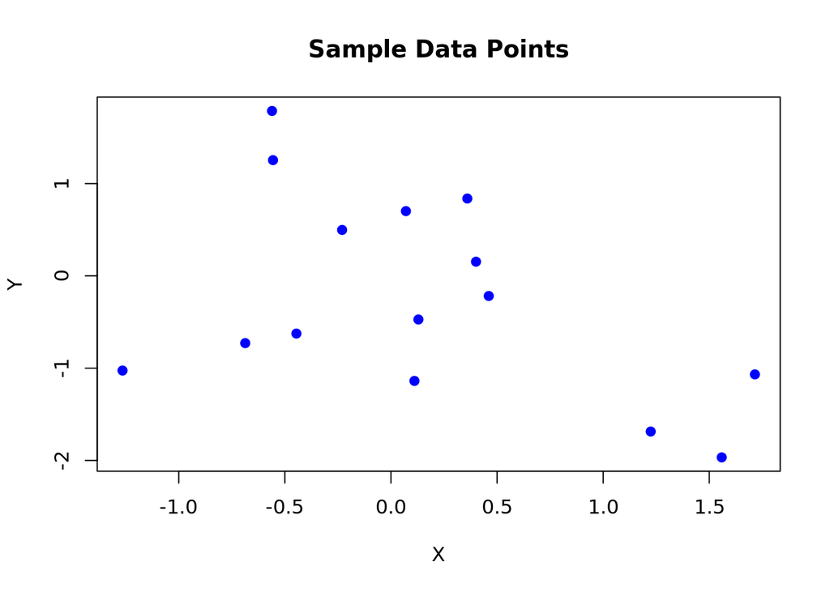

```r
# Sample data
set.seed(123)
data <- matrix(rnorm(30), ncol=2)
colnames(data) <- c("X", "Y")

# Visualize the data
plot(data, pch=19, col="blue", xlab="X", ylab="Y", main="Sample Data Points")
```

```r
dist_matrix <- dist(data)
```

Ahora procedemos a crear el programa ayudado con un paquete de R que ya lo calcula con la función de `hclust` del paquete `stats`. Y programamos para que directamente grafique los dendogramas.

```r
clusterFunc <- function(dist_matrix,method ="single" ){
  if(method=="single"){
    # Single-linkage
    single_linkage <- hclust(dist_matrix, method="single")
    plot(single_linkage, main="Single-linkage Hierarchical Clustering", sub="", xlab="", ylab="Height")
  } else if(method=="average"){
    # Average-linkage
    average_linkage <- hclust(dist_matrix, method="average")
    plot(average_linkage, main="Average-linkage Hierarchical Clustering", sub="", xlab="", ylab="Height")
  } else{
    # Complete-linkage
    complete_linkage <- hclust(dist_matrix, method="complete")
    plot(complete_linkage, main="Complete-linkage Hierarchical Clustering", sub="", xlab="", ylab="Height")
  }
}
```

Y procedemos a probarlo

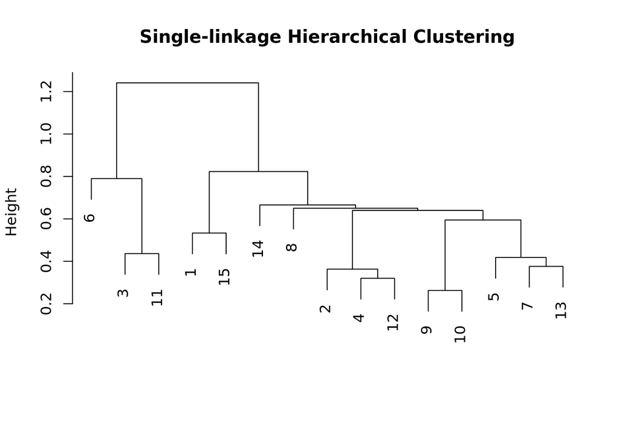

```r
clusterFunc(dist_matrix,method ="single" )
```

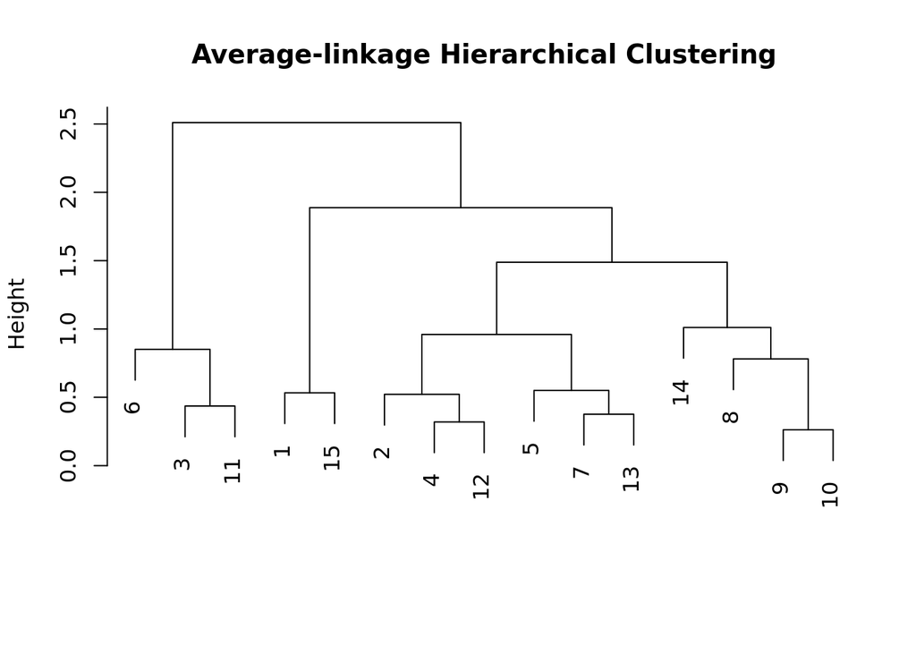

```r
clusterFunc(dist_matrix,method ="average" )
```

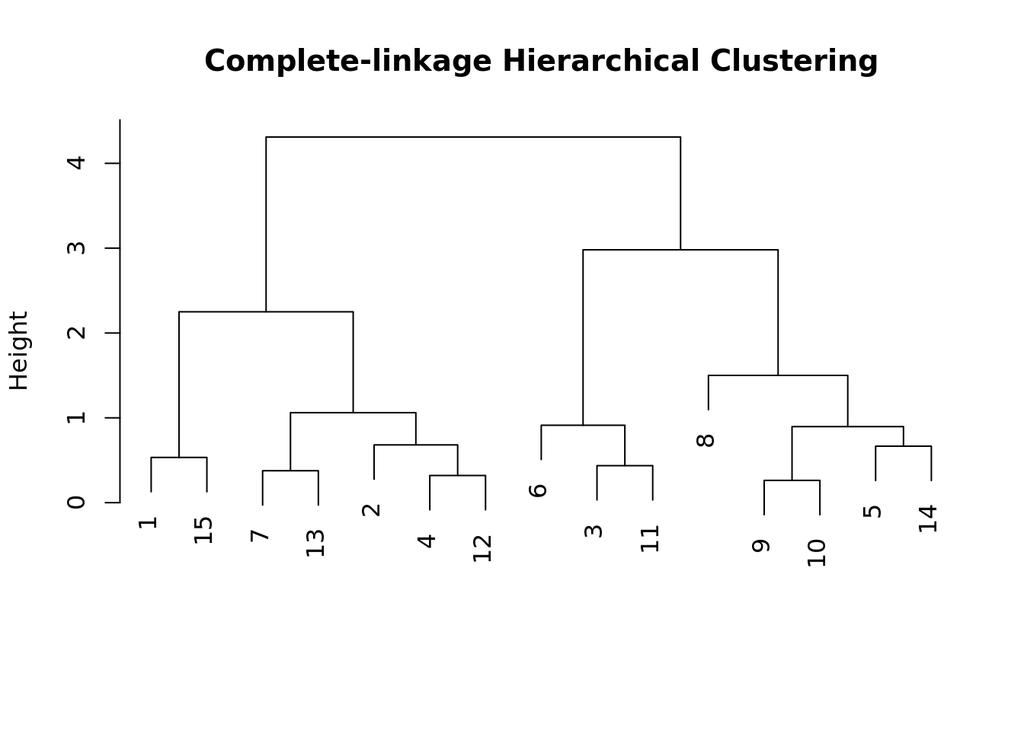

```r
clusterFunc(dist_matrix,method ="complete" )
```

# 8.- Implemente SL, AL y CL sobre la base de datos `iris` (raw data)

Primero inicializamos `iris` y agarramos los datos numéricos de su base de datos

```
library(cluster)

#Iris DB
data <- as.matrix(iris[,1:4])
dist_mat <- dist(data, method = 'euclidean')
```

```
hclust_single <- hclust(dist_mat, method = 'single')
hclust_average <- hclust(dist_mat, method='average')
hclust_complete <- hclust(dist_mat, method= 'complete')
divisive_model <- agnes(dist_mat, method = "single")
```

Los plots resultantes son los siguientes:

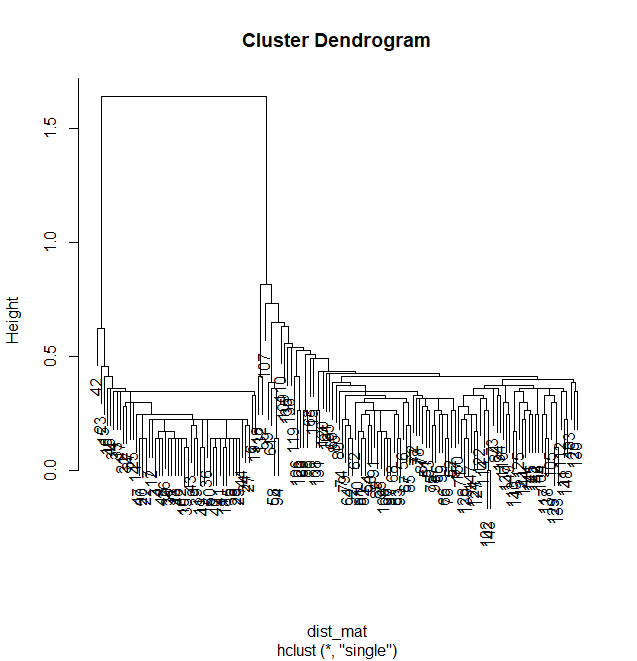

Single Linkage Agglomerative Cluster

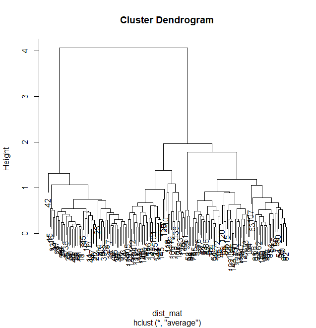

Average Linkage Agglomerative Cluster

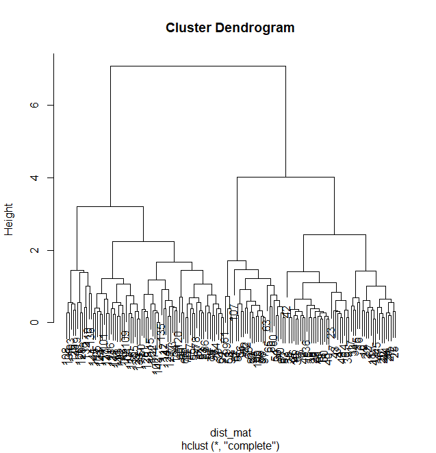

Complete Linkage Agglomerative Cluster

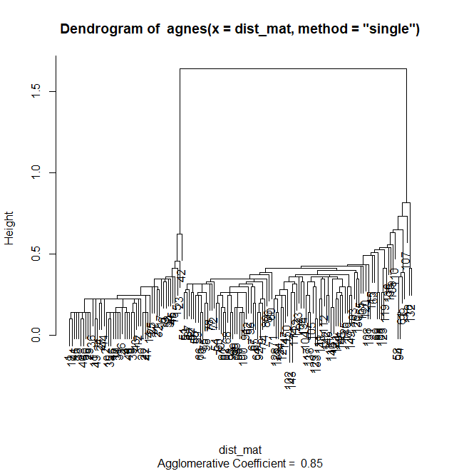

De estas imágenes podemos determinar, junto con el conocimiento previo de que hay **tres** tipos de plantas, que el Complete Linkage Cluster es el que mejor nos permite diferenciar los tipos de planta que tiene la base de datos al hacer un corte horizontal a altura 3.5, mientras que los demás algoritmos tienen problema diferenciando los tipos de especies al tomar diferencias mínimas o promedio de medidas en sépalo y pétalo. Por tanto, **es más fácil diferenciar las especies de plantas por el tamaño máximo de sépalo y pétalo de las plantas, haciendo el Complete Linkage el más efectivo.**

# 9.- Problem 12.13

The following table lists measurements on 5 nutritional variables for 12 breakfast cereals.

```r
library(kableExtra)
cereal_data <- data.frame(
  Cereal = c("Life", "Grape Nuts", "Super Sugar Crisp", "Special K", "Rice Krispies", "Raisin Bran",
             "Product 19", "Wheaties", "Total", "Puffed Rice", "Sugar Corn Pops", "Sugar Smacks"),
  Protein_gm = c(6, 3, 2, 6, 2, 3, 2, 3, 3, 1, 1, 2),
  Carbohydrates_gm = c(19, 23, 26, 21, 25, 28, 24, 23, 23, 13, 26, 25),
  Fat_gm = c(1, 0, 0, 0, 0, 1, 0, 1, 1, 0, 0, 0),
  Calories_per_oz = c(110, 100, 110, 110, 110, 120, 110, 110, 110, 50, 110, 110),
  Vitamin_A_pct_daily_allowance = c(0, 25, 25, 25, 25, 25, 100, 25, 100, 0, 25, 25)
)

kable(cereal_data, "html", booktabs = TRUE) %>%
  kable_styling()
```

| Cereal | Protein_gm | Carbohydrates_gm | Fat_gm | Calories_per_oz | Vitamin_A_pct_daily_allowance |
| --- | --- | --- | --- | --- | --- |
| Life | 6 | 19 | 1 | 110 | 0 |
| Grape Nuts | 3 | 23 | 0 | 100 | 25 |
| Super Sugar Crisp | 2 | 26 | 0 | 110 | 25 |
| Special K | 6 | 21 | 0 | 110 | 25 |
| Rice Krispies | 2 | 25 | 0 | 110 | 25 |
| Raisin Bran | 3 | 28 | 1 | 120 | 25 |
| Product 19 | 2 | 24 | 0 | 110 | 100 |
| Wheaties | 3 | 23 | 1 | 110 | 25 |
| Total | 3 | 23 | 1 | 110 | 100 |
| Puffed Rice | 1 | 13 | 0 | 50 | 0 |
| Sugar Corn Pops | 1 | 26 | 0 | 110 | 25 |
| Sugar Smacks | 2 | 25 | 0 | 110 | 25 |

1. Using tha data in the table, calculate the euclidean distances between each pair of cereal brands.

```r
# Compute the distance matrix
dist_matrix <- dist(cereal_data[1:12,2:6])

kable(as.matrix(dist_matrix),"html",booktabs=TRUE) %>% kable_styling()
```

| 1 | 2 | 3 | 4 | 5 | 6 | 7 | 8 | 9 | 10 | 11 | 12 |
| --- | --- | --- | --- | --- | --- | --- | --- | --- | --- | --- | --- |
| 0.00000 | 27.40438 | 26.286879 | 25.099801 | 26.038433 | 28.54820 | 100.209780 | 25.495098 | 100.124922 | 60.51446 | 26.457513 | 26.038433 |
| 27.40438 | 0.00000 | 10.488088 | 10.630146 | 10.246951 | 20.63977 | 75.676945 | 10.049876 | 75.670338 | 56.82429 | 10.630146 | 10.246951 |
| 26.28688 | 10.48809 | 0.000000 | 6.403124 | 1.000000 | 10.29563 | 75.026662 | 3.316625 | 75.073297 | 66.29480 | 1.000000 | 1.000000 |
| 25.09980 | 10.63015 | 6.403124 | 0.000000 | 5.656854 | 12.60952 | 75.166482 | 3.741657 | 75.093275 | 65.68105 | 7.071068 | 5.656854 |
| 26.03843 | 10.24695 | 1.000000 | 5.656854 | 0.000000 | 10.53565 | 75.006666 | 2.449490 | 75.039989 | 66.10598 | 1.414214 | 0.000000 |
| 28.54820 | 20.63977 | 10.295630 | 12.609520 | 10.535654 | 0.00000 | 75.782584 | 11.180340 | 75.828754 | 75.86172 | 10.440307 | 10.535654 |
| 100.20978 | 75.67695 | 75.026662 | 75.166482 | 75.006666 | 75.78258 | 0.000000 | 75.019997 | 1.732051 | 117.14094 | 75.033326 | 75.006666 |
| 25.49510 | 10.04988 | 3.316625 | 3.741657 | 2.449490 | 11.18034 | 75.019997 | 0.000000 | 75.000000 | 65.80274 | 3.741657 | 2.449490 |
| 100.12492 | 75.67034 | 75.073297 | 75.093275 | 75.039989 | 75.82875 | 1.732051 | 75.000000 | 0.000000 | 117.06836 | 75.093275 | 75.039989 |
| 60.51446 | 56.82429 | 66.294796 | 65.681048 | 66.105975 | 75.86172 | 117.140941 | 65.802735 | 117.068356 | 0.00000 | 66.287254 | 66.105975 |
| 26.45751 | 10.63015 | 1.000000 | 7.071068 | 1.414214 | 10.44031 | 75.033326 | 3.741657 | 75.093275 | 66.28725 | 0.000000 | 1.414214 |
| 26.03843 | 10.24695 | 1.000000 | 5.656854 | 0.000000 | 10.53565 | 75.006666 | 2.449490 | 75.039989 | 66.10598 | 1.414214 | 0.000000 |

2. Treating the distances calculated in (a) as measures of dissimilarity, use single-linkage, complete-linkage, and average-linkage clustering to cluster the cereal brands. Construct a dendrogram for each method.

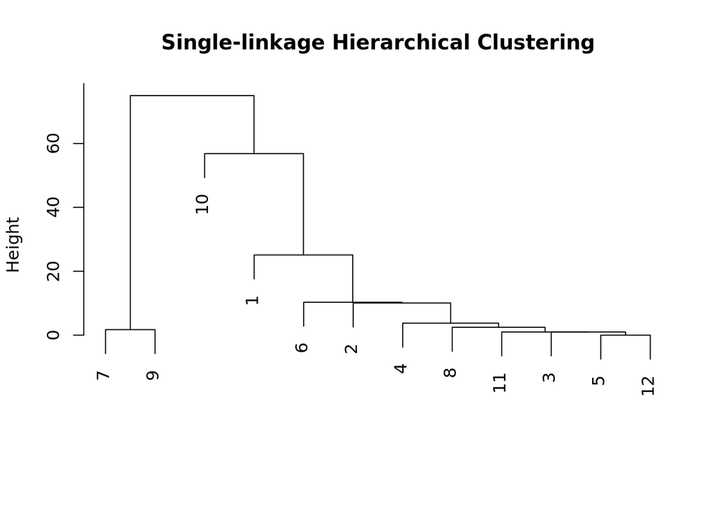

```r
clusterFunc(dist_matrix,method ="single" )
```

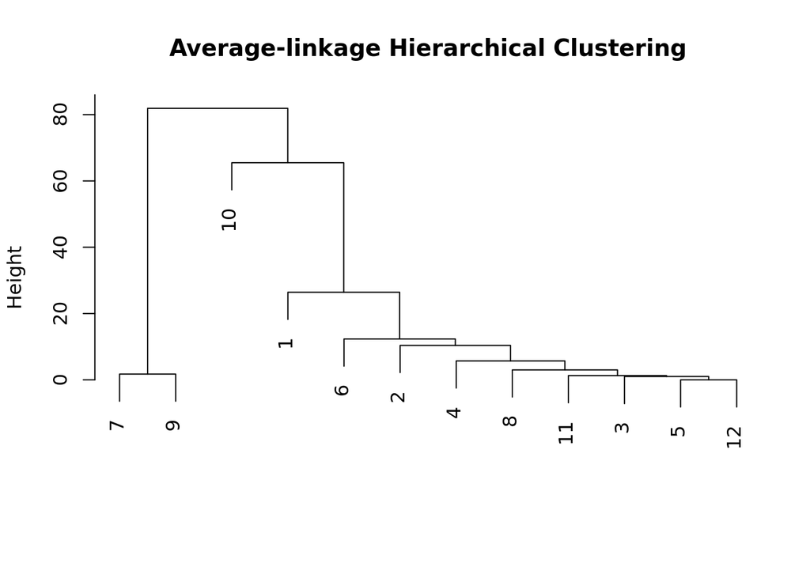

```r
clusterFunc(dist_matrix,method ="average" )
```

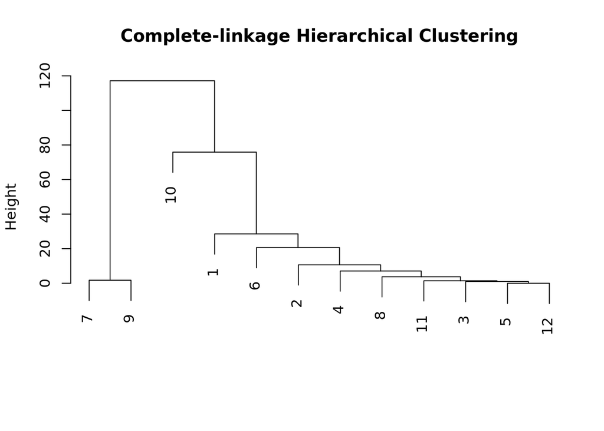

```r
clusterFunc(dist_matrix,method ="complete" )
```

De estas imágenes podemos determinar de que hay casi **tres** tipos de cereales. Y en los 3 métodos los dendogramas se parecen muchísimo. Con lo cual es mucho más fácil concordar en los distintos clusters que se pueden hacer a diferencia del anterior.

# 10.- Input the data in the previous table into k-means clustering program. Use the program to cluster the cereal brands into 2, 3, and 4 clusters. Compare the results with those obtained in the previous problem.

## Utilizamos K=2

```r
# Exclude the Cereal column
clustering_data <- cereal_data[,-1]

# Choose the optimal number of clusters (for demonstration, let's say 3)
set.seed(123)  # Set seed for reproducibility
clusters <- kmeans(clustering_data, centers=2, nstart=20)

# Add cluster results to the original data
cereal_data$cluster <- as.factor(clusters$cluster)

kable(cereal_data, "html", booktabs = TRUE) %>%
kable_styling()
```

| Cereal | Protein_gm | Carbohydrates_gm | Fat_gm | Calories_per_oz | Vitamin_A_pct_daily_allowance | cluster |
| --- | --- | --- | --- | --- | --- | --- |
| Life | 6 | 19 | 1 | 110 | 0 | 2 |
| Grape Nuts | 3 | 23 | 0 | 100 | 25 | 2 |
| Super Sugar Crisp | 2 | 26 | 0 | 110 | 25 | 2 |
| Special K | 6 | 21 | 0 | 110 | 25 | 2 |
| Rice Krispies | 2 | 25 | 0 | 110 | 25 | 2 |
| Raisin Bran | 3 | 28 | 1 | 120 | 25 | 2 |
| Product 19 | 2 | 24 | 0 | 110 | 100 | 1 |
| Wheaties | 3 | 23 | 1 | 110 | 25 | 2 |
| Total | 3 | 23 | 1 | 110 | 100 | 1 |
| Puffed Rice | 1 | 13 | 0 | 50 | 0 | 2 |
| Sugar Corn Pops | 1 | 26 | 0 | 110 | 25 | 2 |
| Sugar Smacks | 2 | 25 | 0 | 110 | 25 | 2 |

## Utilizamos K=3

```r
clusters <- kmeans(clustering_data, centers=3, nstart=20)

# Add cluster results to the original data
cereal_data$cluster <- as.factor(clusters$cluster)

# Print the dataframe with clusters
kable(cereal_data, "html", booktabs = TRUE) %>%
kable_styling()
```

| Cereal | Protein_gm | Carbohydrates_gm | Fat_gm | Calories_per_oz | Vitamin_A_pct_daily_allowance | cluster |
| --- | --- | --- | --- | --- | --- | --- |
| Life | 6 | 19 | 1 | 110 | 0 | 1 |
| Grape Nuts | 3 | 23 | 0 | 100 | 25 | 1 |
| Super Sugar Crisp | 2 | 26 | 0 | 110 | 25 | 1 |
| Special K | 6 | 21 | 0 | 110 | 25 | 1 |
| Rice Krispies | 2 | 25 | 0 | 110 | 25 | 1 |
| Raisin Bran | 3 | 28 | 1 | 120 | 25 | 1 |
| Product 19 | 2 | 24 | 0 | 110 | 100 | 2 |
| Wheaties | 3 | 23 | 1 | 110 | 25 | 1 |
| Total | 3 | 23 | 1 | 110 | 100 | 2 |
| Puffed Rice | 1 | 13 | 0 | 50 | 0 | 3 |
| Sugar Corn Pops | 1 | 26 | 0 | 110 | 25 | 1 |
| Sugar Smacks | 2 | 25 | 0 | 110 | 25 | 1 |

## Utilizamos K=4

```r
clusters <- kmeans(clustering_data, centers=4, nstart=20)

# Add cluster results to the original data
cereal_data$cluster <- as.factor(clusters$cluster)

# Print the dataframe with clusters
kable(cereal_data, "html", booktabs = TRUE) %>%
kable_styling()
```

| Cereal | Protein_gm | Carbohydrates_gm | Fat_gm | Calories_per_oz | Vitamin_A_pct_daily_allowance | cluster |
| --- | --- | --- | --- | --- | --- | --- |
| Life | 6 | 19 | 1 | 110 | 0 | 4 |
| Grape Nuts | 3 | 23 | 0 | 100 | 25 | 3 |
| Super Sugar Crisp | 2 | 26 | 0 | 110 | 25 | 3 |
| Special K | 6 | 21 | 0 | 110 | 25 | 3 |
| Rice Krispies | 2 | 25 | 0 | 110 | 25 | 3 |
| Raisin Bran | 3 | 28 | 1 | 120 | 25 | 3 |
| Product 19 | 2 | 24 | 0 | 110 | 100 | 1 |
| Wheaties | 3 | 23 | 1 | 110 | 25 | 3 |
| Total | 3 | 23 | 1 | 110 | 100 | 1 |
| Puffed Rice | 1 | 13 | 0 | 50 | 0 | 2 |
| Sugar Corn Pops | 1 | 26 | 0 | 110 | 25 | 3 |
| Sugar Smacks | 2 | 25 | 0 | 110 | 25 | 3 |

Notamos que los clusters que se van formando en k-means son los mismos que se formarían si nos vamos desplazando continuamente en la altura a la cual decidimos cortar de cualquiera de los dendogramas. Por lo tanto se llegan a las mismas conclusiones que utilizando los dendogramas y en este caso serían equivalentes.